# Coevolution with a seed bank: population density

## Population density data

I have previously consolidated all the data on population density collected for this experiment. This includes:

| Population | What it is | Method of measurement |
| --- | --- | --- |
| spore / mL | host spore density | flow-cytometry: low SYBR population |
| veg / mL | host vegetative cell density | flow-cytometry: high SYBR population |
| cell /mL | total host cell density (spore+veg) | flow-cytometry |
| phage/ mL | total SPO1 phage density (free phage) | qPCR (SYBR) with phage specific primers and lysate serial dilution as standard |

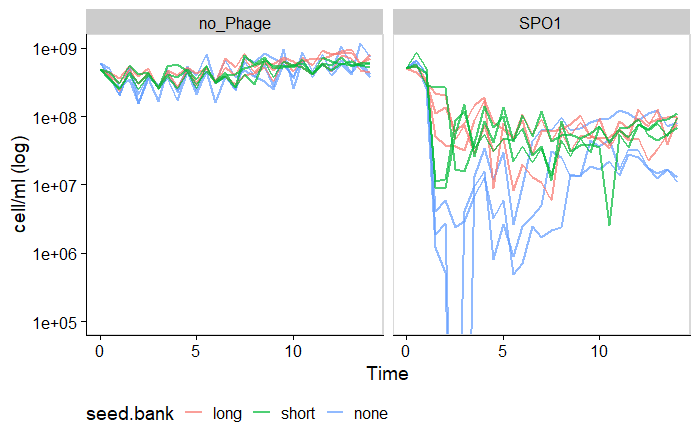

### Decomposition of the time series

From QB handout on temporal diversity:

> A time series can be broken down into different “categories”, which can provide insight into factors contributing to temporal patterns.  
> The common categories of a time series decomposition are the trend (i.e., increasing or decreasing value in the series), seasonality (repeating short-term cycles), and residual error (i.e., statistical noise due to stochastic changes or sampling error).

First let’s look at decomposition of a single sample (WSO-L1), looking at total cells.

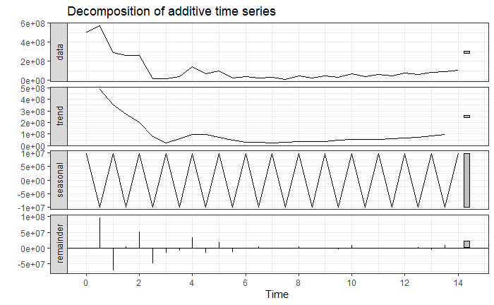

The decomposition removes the bi-daily fluctuations (season component) and reveals 2 population cycles in the first week, followed by a steady rise in the second week.

Next let’s decompose in the same manner all of the data.

### Plot decomposed trend data

Plot by treatment, as above.

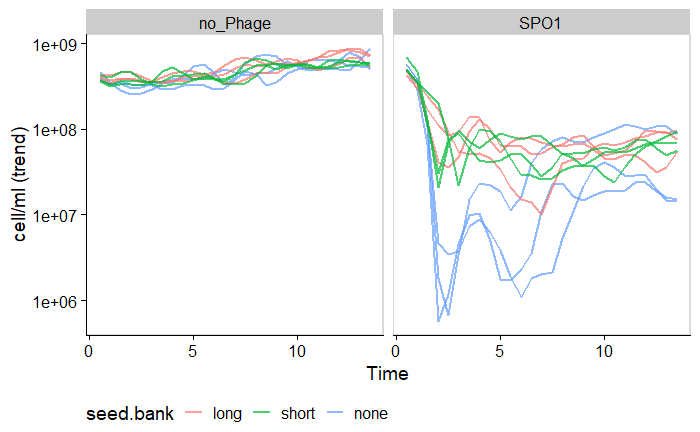

The patterns are somewhat clearer. Especially obvious is the differences between WT (long and short seed bank) and SPOIIE (no seed bank) in the first week when infected with phage. The 3 lines with the non-sporulating mutant all have similar looking cycles.

And now adding to total cells also the phages.

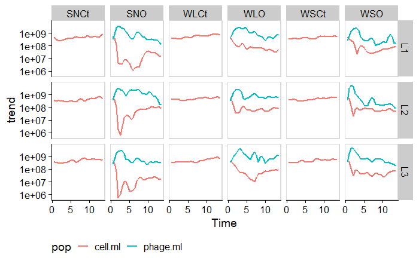

```r
d.decomp%>%
  filter(!is.na(trend))%>%
  filter(pop=="cell.ml" | pop=="phage.ml")%>%
  ggplot(aes(x=Time, y=trend))+
  geom_line(aes(color=pop), size=1)+
  facet_grid(line~culture)+
  theme_cowplot()+
  panel_border()+
  scale_y_log10()+
  theme(legend.position = "bottom")
```

Next plotting all the decomposed trend data: spores, veg and phages.

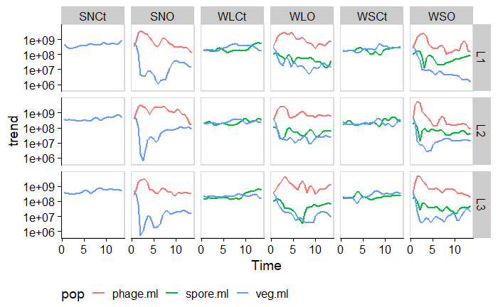

```r
d.decomp%>%
  filter(!is.na(trend))%>%
  filter(pop!="cell.ml")%>%
  ggplot(aes(x=Time, y=trend))+
  geom_line(aes(color=pop), size=1)+
  facet_grid(line~culture)+
  theme_cowplot()+
  panel_border()+
  scale_y_log10()+
  theme(legend.position = "bottom")
```

```r
NA
```

Finally pulling together spore and veg data from the 3 seed bank treatments:

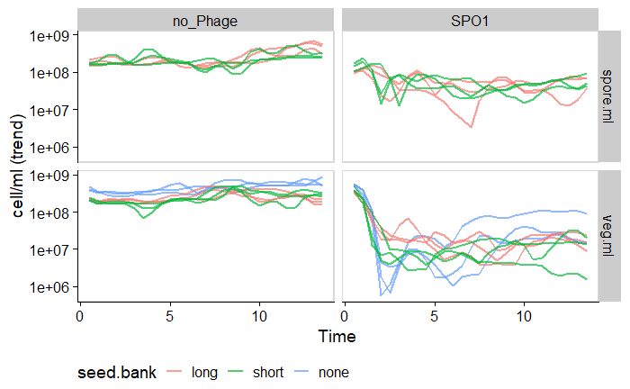

```r
d.decomp%>%
  #remove edges in which trend is NA
  filter(!is.na(trend))%>%
  # looking only at cells by type
  filter(pop=="spore.ml" | pop=="veg.ml")%>%
  ggplot(aes(x=Time, y=trend))+
  geom_line(aes(group=flask,color=seed.bank), size=1, alpha=0.7)+
  facet_grid(pop~phage)+
  theme_cowplot()+
  panel_border()+
  scale_y_log10()+
  theme(legend.position = "bottom")+
  ylab("cell/ml (trend)")
```

```r
NA
```

# Stability

From QB:

> The stability of an aggregate measure of an ecological system can be assessed by measuring its variability. One way to characterize variability is the Coefficient of Variation (CV). The CV relativizes the standard deviation of a variable to its mean value because variance scales with the mean. By using the CV, we can more easily compare the variability of systems with different mean values. We can calculate the CV as follows:
> $$CV = \frac{\sigma}{\mu}$$
> where $\sigma$ is the standard deviation and $\mu$ is the mean value. Higher CV indicates more variability, and lower CV indicates less variability. Therefore, we can measure stability as the inverse of CV:
> $$\textrm{Stability} = \frac{1}{CV}$$

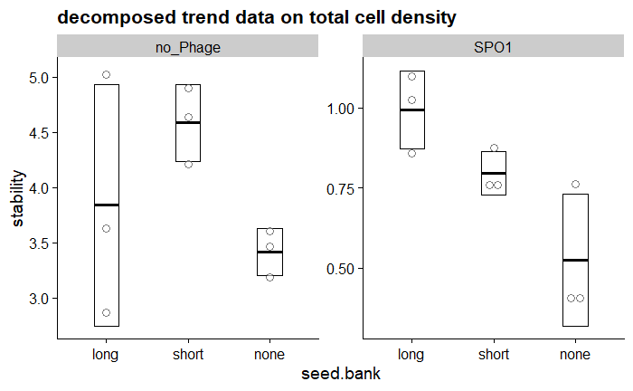

In the presence of phage, the presence of a seed bank stabilizes the host population!!

Now the same analysis with the observed data

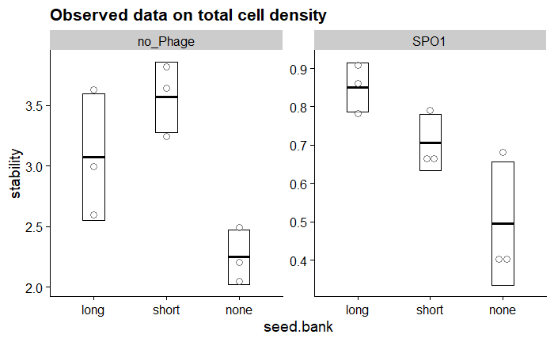

Almost exactly the same. Is there statistical support for seed bank stability?

I will test this seperatly for w. and w/o phage

```r
aov_stab <-
  aov(stability~seed.bank,
    data = filter(cell.stab, phage=="SPO1"))

summary(aov_stab)
```

```
            Df  Sum Sq Mean Sq F value Pr(>F)
seed.bank    2 0.19088 0.09544   8.094 0.0198 *
Residuals    6 0.07075 0.01179
---
Signif. codes:  0 ‘***’ 0.001 ‘**’ 0.01 ‘*’ 0.05 ‘.’ 0.1 ‘ ’ 1
```

Yes, there is! Post-hoc:

```r
tuk <- TukeyHSD(aov_stab)

tuk
```

```
  Tukey multiple comparisons of means
    95% family-wise confidence level

Fit: aov(formula = stability ~ seed.bank, data = filter(cell.stab, phage == "SPO1"))

$seed.bank
                 diff        lwr         upr     p adj
short-long -0.1431079 -0.4151516  0.12893578 0.3106848
none-long  -0.3545425 -0.6265862 -0.08249884 0.0167609
none-short -0.2114346 -0.4834783  0.06060905 0.1182525
```

[output not shown]

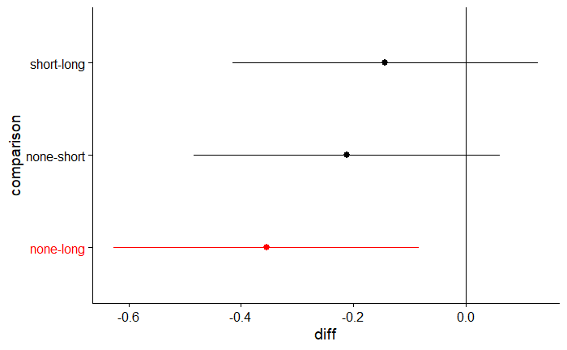

```r
# I wrote a function to nicely plot the results of this test
source(here("code","functions", "plot_TukeyHSD.R"))

plot_TukeyHSD (tuk)
```

The difference in stability is driven by a significant difference in stability between the long-residence seed-bank and the no seed-bank treatments. the short-residence seed-bank is not significantly distinguishable from either of the other treatments.

Now in no-phage flasks:

```r
aov_stab <-
  aov(stability~seed.bank,
    data = filter(cell.stab, phage!="SPO1"))

summary(aov_stab)
```

```
            Df Sum Sq Mean Sq F value Pr(>F)
seed.bank    2 2.6704  1.3352   9.853 0.0127 *
Residuals    6 0.8131  0.1355
---
Signif. codes:  0 ‘***’ 0.001 ‘**’ 0.01 ‘*’ 0.05 ‘.’ 0.1 ‘ ’ 1
```

Yes, there is! Post-hoc:

```r
tuk <- TukeyHSD(aov_stab)

tuk
```

```
  Tukey multiple comparisons of means
    95% family-wise confidence level

Fit: aov(formula = stability ~ seed.bank, data = filter(cell.stab, phage != "SPO1"))

$seed.bank
                 diff        lwr         upr     p adj
short-long  0.4948856 -0.4273381  1.41710926 0.2988212
none-long  -0.8256435 -1.7478672  0.09658023 0.0746353
none-short -1.3205290 -2.2427527 -0.39830534 0.0109137
```

[output not shown]

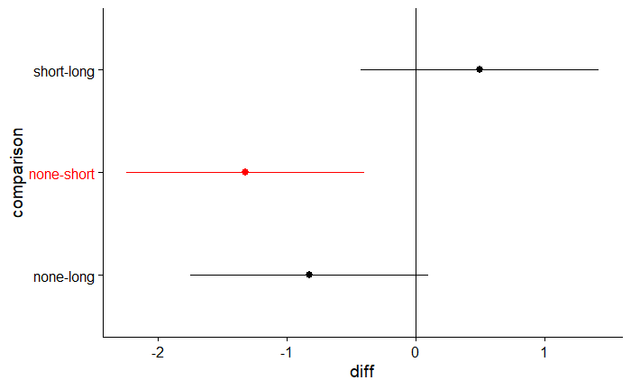

```r
plot_TukeyHSD (tuk)
```

once again there is a difference between no-seed-bank and one of the seed bak treatments. here it is the short. Maybe it is more of an effect of spre presence or absece than the actual seed bank treatment.

### stability by host

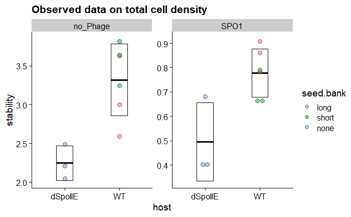

```r
#summarise
sum.cell.stab <-
  cell.stab%>%
    group_by(host,phage) %>%
    summarise(
      sd = sd(stability),
      stability = mean(stability))


  # plot
cell.stab%>%
  ggplot(aes(x=host, y=stability))+
  geom_crossbar(data=sum.cell.stab,
                  aes(ymin=stability-sd, ymax=stability+sd), width=0.3)+
  geom_dotplot(aes(fill=seed.bank),binaxis='y', stackdir='center', alpha=0.5)+
  # geom_jitter(shape=21, fill="grey", size=2, width = 0.05, height = 0)+
  facet_wrap(~phage, scales = "free")+
  theme_cowplot()+
  ggtitle("Observed data on total cell density")
```

```r
aov_stab <-
  aov(stability~host*phage,
          data = cell.stab)
    # data = filter(cell.stab, phage!="SPO1"))

summary(aov_stab)
```

```
            Df Sum Sq Mean Sq F value   Pr(>F)
host         1  1.839   1.839  20.083 0.000517 ***
phage        1 23.375  23.375 255.282  2.2e-10 ***
host:phage   1  0.624   0.624   6.818 0.020530 *
Residuals   14  1.282   0.092
---
Signif. codes:  0 ‘***’ 0.001 ‘**’ 0.01 ‘*’ 0.05 ‘.’ 0.1 ‘ ’ 1
```

Yes, there is! Post-hoc:

```r
tuk <- TukeyHSD(aov_stab)

tuk
```

```
  Tukey multiple comparisons of means
    95% family-wise confidence level

Fit: aov(formula = stability ~ host * phage, data = cell.stab)

$host
                diff       lwr     upr     p adj
WT-dSpoIIE 0.6780374 0.3535348 1.00254 0.0005172

$phage
                   diff       lwr       upr p adj
SPO1-no_Phage -2.279123 -2.585067 -1.973179     0

$`host:phage`
                                    diff        lwr        upr     p adj
WT:no_Phage-dSpoIIE:no_Phage   1.0730862  0.4511736  1.6949989 0.0009612
dSpoIIE:SPO1-dSpoIIE:no_Phage -1.7523912 -2.4705140 -1.0342684 0.0000287
WT:SPO1-dSpoIIE:no_Phage      -1.4694026 -2.0913152 -0.8474900 0.0000408
dSpoIIE:SPO1-WT:no_Phage      -2.8254774 -3.4473900 -2.2035648 0.0000000
WT:SPO1-WT:no_Phage           -2.5424889 -3.0502784 -2.0346993 0.0000000
WT:SPO1-dSpoIIE:SPO1           0.2829886 -0.3389240  0.9049012 0.5644982
```

[output not shown]

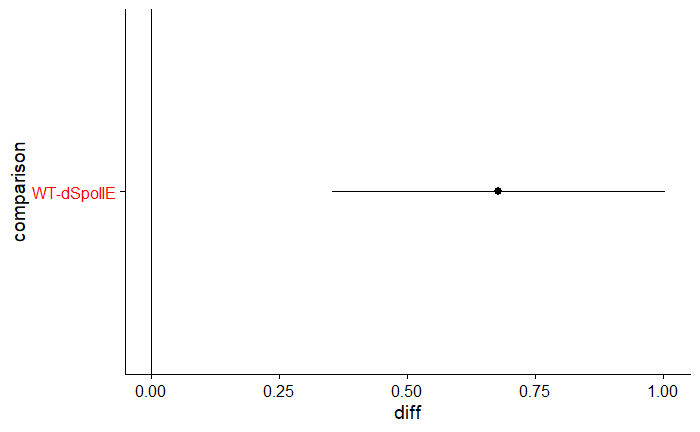

```r
plot_TukeyHSD (tuk)
```

# Repeated-Measures Analysis-of-Variance (RM-ANOVA)

*Following QB module*

## RM-ANOVA on decomposed trend total cell data

```r
cell.rm.decomp <-
  d.decomp%>%
  # looking only at total cells
  filter(pop=="cell.ml")%>%
  lme(trend ~ phage * seed.bank * Time , random = ~1|flask,
            correlation = corAR1(form = ~ Time|flask),
            data = .,
      #remove edges in which trend is NA
      na.action = "na.omit")

# Look at detailed output
summary(cell.rm.decomp)
```

```
Linear mixed-effects model fit by REML
 Data: .
```

|  | AIC | BIC | logLik |
| --- | --- | --- | --- |
|  | 18422.75 | 18485.17 | -9196.377 |

```
Random effects:
 Formula: ~1 | flask
        (Intercept) Residual
StdDev:    26497.05 63002711

Correlation Structure: ARMA(1,0)
 Formula: ~Time | flask
 Parameter estimate(s):
     Phi1
0.7672739
Fixed effects: trend ~ phage * seed.bank * Time
```

|  | Value | Std.Error | DF | t-value | p-value |
| --- | --- | --- | --- | --- | --- |
| (Intercept) | 368769429 | 35132333 | 462 | 10.496582 | 0.0000 |
| phageSPO1 | 37916424 | 49684622 | 12 | 0.763142 | 0.4601 |
| seed.bankshort | -15644273 | 49684622 | 12 | -0.314872 | 0.7583 |
| seed.banknone | -5023578 | 49684622 | 12 | -0.101109 | 0.9211 |
| Time | 23416636 | 5704760 | 462 | 4.104754 | 0.0000 |
| phageSPO1:seed.bankshort | 97290292 | 70264667 | 12 | 1.384626 | 0.1914 |
| phageSPO1:seed.banknone | 57014453 | 70264667 | 12 | 0.811424 | 0.4329 |
| phageSPO1:Time | -57544029 | 8067749 | 462 | -7.132600 | 0.0000 |
| seed.bankshort:Time | -6527454 | 8067749 | 462 | -0.809080 | 0.4189 |
| seed.banknone:Time | -6778080 | 8067749 | 462 | -0.840145 | 0.4013 |

[output cut: 2 more lines]

```
 Correlation:
                              (Intr) phSPO1 sd.bnks sd.bnkn Time   phgSPO1:sd.bnks
phageSPO1                     -0.707
seed.bankshort                -0.707  0.500
seed.banknone                 -0.707  0.500  0.500
Time                          -0.621  0.439  0.439   0.439
phageSPO1:seed.bankshort       0.500 -0.707 -0.707  -0.354  -0.311
phageSPO1:seed.banknone        0.500 -0.707 -0.354  -0.707  -0.311  0.500
phageSPO1:Time                 0.439 -0.621 -0.311  -0.311  -0.707  0.439
seed.bankshort:Time            0.439 -0.311 -0.621  -0.311  -0.707  0.439
seed.banknone:Time             0.439 -0.311 -0.311  -0.621  -0.707  0.220
phageSPO1:seed.bankshort:Time -0.311  0.439  0.439   0.220   0.500 -0.621
phageSPO1:seed.banknone:Time  -0.311  0.439  0.220   0.439   0.500 -0.311
                              phgSPO1:sd.bnkn pSPO1:T sd.bnks:T sd.bnkn:T
phageSPO1
seed.bankshort
seed.banknone
Time
phageSPO1:seed.bankshort
phageSPO1:seed.banknone
phageSPO1:Time                 0.439
seed.bankshort:Time            0.220           0.500
seed.banknone:Time             0.439           0.500   0.500
phageSPO1:seed.bankshort:Time -0.311          -0.707  -0.707    -0.354
phageSPO1:seed.banknone:Time  -0.621          -0.707  -0.354    -0.707
                              phgSPO1:sd.bnks:T
phageSPO1
seed.bankshort
seed.banknone
Time
phageSPO1:seed.bankshort
phageSPO1:seed.banknone
phageSPO1:Time
seed.bankshort:Time
seed.banknone:Time
phageSPO1:seed.bankshort:Time
phageSPO1:seed.banknone:Time   0.500

Standardized Within-Group Residuals:
       Min         Q1        Med         Q3        Max
-6.0550094 -2.0546047 -0.6996872  0.5332525  4.6826665

Number of Observations: 486
Number of Groups: 18
```

```r
# Obtain F-test
anova(cell.rm.decomp)
```

|  | numDF | denDF | F-value | p-value |
| --- | --- | --- | --- | --- |
| (Intercept) | 1 | 462 | 1064.5668 | <.0001 |
| phage | 1 | 12 | 36.2787 | 0.0001 |
| seed.bank | 2 | 12 | 0.0544 | 0.9473 |
| Time | 1 | 462 | 19.9453 | <.0001 |
| phage:seed.bank | 2 | 12 | 1.3125 | 0.3051 |
| phage:Time | 1 | 462 | 159.1686 | <.0001 |
| seed.bank:Time | 2 | 462 | 1.1737 | 0.3101 |
| phage:seed.bank:Time | 2 | 462 | 0.0193 | 0.9809 |

```r
# # Use `lsmeans` package for time-corrected marginal means
# lsmeans(cell.rm, ~seed.bank+phage)  %>% plot()+theme_cowplot()
```

## RM-ANOVA on measured total cell data

```r
cell.rm.obs <-
  d%>%
  # remove setup data
  filter(Time>=0)%>%

  #make time an integer for corelation structure
  # by converting to days as time unit
  mutate(Time=as.integer(2*Time))%>%

  # for the lme model all fixed effects need to be factors
  mutate(time.fct=as.factor(Time))%>%
  mutate(seed.bank=as.factor(seed.bank))%>%
  mutate(phage=as.factor(phage))%>%

  lme(cell.ml ~ phage * seed.bank * time.fct ,
        random = ~1|flask,
      correlation = corAR1(form = ~Time|flask),
      data=.)

# Obtain F-test
anova(cell.rm.obs)


plot(cell.rm.obs, type='l')
# # Use `lsmeans` package for time-corrected marginal means
# lsmeans(cell.rm.obs, ~seed.bank+phage)  %>% plot()+theme_cowplot()
```

[output not shown]

# testing for staionarity

```r
for(f in unique(d$flask)){
  print(f)
}
```

```
[1] "SNO-L1"
[1] "SNO-L2"
[1] "SNO-L3"
[1] "WLO-L1"
[1] "WLO-L2"
[1] "WLO-L3"
[1] "WSO-L1"
[1] "WSO-L2"
[1] "WSO-L3"
[1] "SNCt-L1"
[1] "SNCt-L2"
[1] "SNCt-L3"
[1] "WLCt-L1"
[1] "WLCt-L2"
[1] "WLCt-L3"
[1] "WSCt-L1"
[1] "WSCt-L2"
[1] "WSCt-L3"
```